# Probability and Distributions

Arnab Aich

## Introduction

- A **random experiment** is an action or process that leads to one of several possible outcomes.
  - Example: Flipping a coin or rolling a die.
- An **outcome** is the result of a single trial of a random experiment.
  - Example outcomes: **Coin toss**: Heads or Tails, **Die roll**: 1, 2, 3, 4, 5, 6.
- An **event** is a specific outcome or set of outcomes from a random experiment.
  - Example event: Flipping two heads in a row, or rolling an even number.

## Probability and Distributions

- **Probability** measures the likelihood that an event will occur.
- **Properties:** Probability is always a number between 0 and 1.
  - 0 means the event will **not happen**.
  - 1 means the event **will definitely happen**.
  - The sum of the probabilities for all possible outcomes in a sample space is always equal to **1**.
  - The Probability of an event $A$ is denoted as $P(A)$ and Probability of compliment of event $A$ is denoted as $P(A^c)$. We always have
    $$P(A) + P(A^c) = 1$$
  - If $A$ and $B$ are two independent events, then the probability of them occurring together is given by
    $$P(A \text{ and }B) = P(A) \times
    P(B)$$

  Example: Probability of getting a head in a coin toss is 0.5, and probability of getting a head in a second coin toss is also 0.5. So, the probability of getting two heads in a row is 0.5 * 0.5 = 0.25.
  - If $A$ and $B$ are two independent events, then the probability of either of them occuring is given by
    $$P(A \text{ or } B) = P(A) + P(B)$$

  Example: Probability of getting $1$ in a die roll is $\frac{1}{6}$, and probability of getting $2$ in a die roll is also $\frac{1}{6}$. So, the probability of getting either $1$ or $2$ in a die roll is $\frac{1}{6} + \frac{1}{6} - 0 = \frac{1}{3}$.
- There are two types of probability distributions:
  - **Discrete**: Consists of distinct, countable outcomes.

    Example: The number of heads in 10 coin tosses.
  - **Continuous**: Involves a range of possible outcomes.

    Example: The IQ scores of 1000 individuals.

## Discrete Distribution

- A biased die is tossed **1000** times, and the number of times each face value appears is recorded.
- The frequency and relative frequency of each outcome will be calculated.

| Die.Face | Frequency | Relative.Frequency |
| --- | --- | --- |
| 1 | 170 | 0.170 |
| 2 | 163 | 0.163 |
| 3 | 392 | 0.392 |
| 4 | 99 | 0.099 |
| 5 | 117 | 0.117 |
| 6 | 59 | 0.059 |

## Barplot for Discrete PD

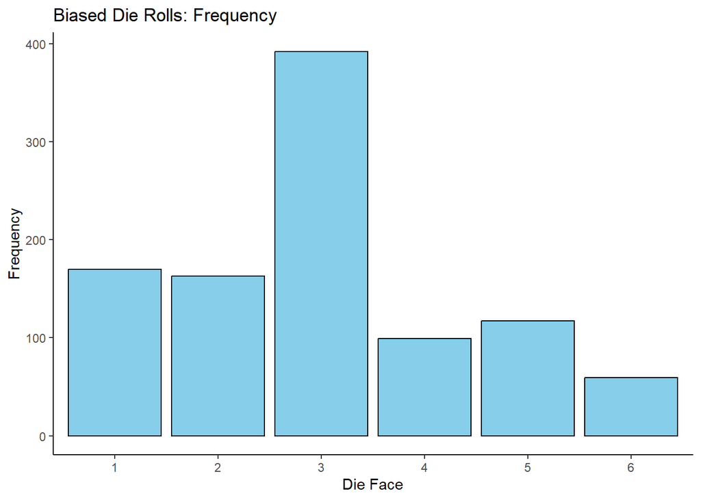

## Continuous Distribution

- An experiment was conducted at a university and IQ scores of 1000 undergraduate students were recorded.
- The table below shows the frequency and relative frequency of IQ ranges.

[output not shown]

## Histogram for Cont. PD

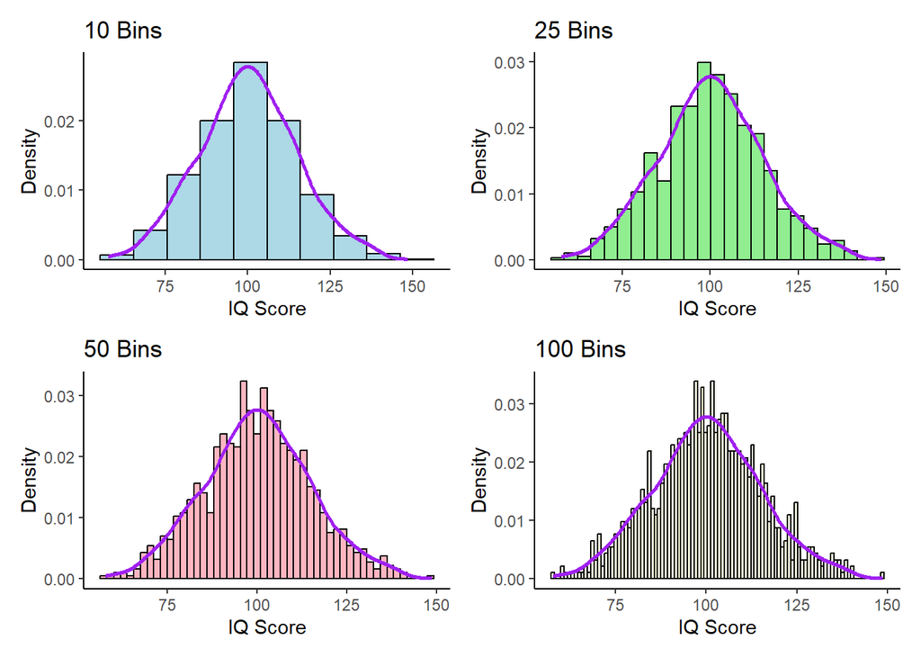

## Recap

- **Relative frequency** measures how often an event occurs, relative to the total number of trials.
- As the number of trials increases, the relative frequency approaches the **true probability** of the event.
- For continuous probability distributions, **probability** can be considered as the **area under the curve**.
- In this way, relative frequency can serve as an estimate of probability, especially in practical applications where the true probability is unknown.

## Q&A Session

#### Question 1: What is a random experiment? Can you give an example?

- **Answer**: A random experiment is a process or action that leads to one of several possible outcomes, where the outcome is uncertain.
- **Example**: Flipping a coin is a random experiment because the result could be either “heads” or “tails,” and we cannot predict which will occur in advance.

#### Question 2: What is an outcome, and how is it different from an event?

- **Answer**: An outcome is the result of a single trial of a random experiment. An event is a set of one or more outcomes.
- **Example**: When rolling a die, getting a “3” is an outcome. The event of rolling an even number includes the outcomes “2”, “4”, and “6.”

#### Question 3: What does it mean when the probability of an event is 0? What about when it’s 1?

- **Answer**: A probability of **0** means the event will **never happen**, while a probability of **1** means the event will **definitely happen**.
- **Example**: If you’re rolling a standard six-sided die, the probability of rolling a “7” is 0 because it’s impossible. The probability of rolling a number between 1 and 6 is 1 because it’s certain.

#### Question 4: How is probability related to frequency, and why is it important?

- **Answer**: Probability can be thought of as the long-term relative frequency of an event. The more times you perform an experiment, the closer the relative frequency of an outcome will match its probability.
- **Example**: If you flip a fair coin many times, you’ll see that approximately 50% of the outcomes will be heads, and 50% will be tails, matching the theoretical probability of 0.5.

#### Question 5: How can knowing probabilities help us make decisions about the future ?

- **Answer**: Probabilities help us evaluate the likelihood of various outcomes, which can inform decision-making. By understanding the chances of different events, we can make more informed and rational choices.
- **Example**: If the probability of rain tomorrow is 90%, you might decide to carry an umbrella when leaving the house.

#### Question 6: What is the difference between discrete and continuous probability distributions?

- **Answer**: A **discrete probability distribution** deals with distinct, countable outcomes (e.g., number of heads in 10 coin flips). A **continuous probability distribution** deals with an infinite number of possible outcomes within a range (e.g., a person’s exact height).
- **Example**: Rolling a die is a discrete distribution because the outcomes (1, 2, 3, etc.) are countable. Measuring someone’s height is a continuous distribution because height can take any value within range.